# Fitting the AR(1) model to empirical data

Sophie W. Berkhout

5-10-2026

### Data from Peter Groot

We will use a data set from Wichers et al. (2016) that is openly available (see Kossakowski et al., 2017). The data set is from a single male participant who was measured for 239 days with 10 ESM measurement occasions per day. The reason for the data collection was to study changes while the participant was gradually reducing his anti-depressant dosage to zero. The study was divided into five phases:

1. a baseline period
2. a double-blind period where the anti-depressant dosage was not changed
3. a double-blind period where the anti-depressant dosage was reduced to zero
4. a post-assessment period where the anti-depressant dosage was not changed
5. an additional post-assessment period.

Wichers et al. (2016) showed that the participant transitioned into a state of depression during the post-dosage reduction period by studying the weekly depressive symptoms measurements.

### Read data

The original data has many different variables, including daily and weekly measurements, but we will only look at two ESM items for simplicity. The data set contains the following variables:

- `date`: the date of the observation
- `time`: the recording time of the observation
- `phase`: the phase of the study (coded 1-5, see above)
- `beep`: the beep number per day (1-10 beeps per day)
- `selfdoubt`: “I doubt myself” scaled from 1 (not) to 7 (very)
- `tired`: “I am tired” scaled from 1 (not) to 7 (very)

```r
dat <- read.csv("data_groot.csv")
```

Since our model assumes a stable process over time, the model will likely not fit the period in the study where the anti-depressant dosage was changed. Therefore, we will only consider the pre-dosage reduction stage.

```r
dat <- subset(dat, phase == 1)
dat
```

|  | date | time | phase | beep | selfdoubt | tired |
| --- | --- | --- | --- | --- | --- | --- |
| 1 | 13/08/12 | 08:58:56 | 1 | 1 | 1 | 1 |
| 2 | 14/08/12 | 14:32:09 | 1 | 5 | 2 | 2 |
| 3 | 14/08/12 | 16:17:13 | 1 | 6 | 1 | 1 |
| 4 | 14/08/12 | 18:04:10 | 1 | 8 | 1 | 2 |
| 5 | 14/08/12 | 20:58:23 | 1 | 9 | 3 | 3 |
| 6 | 14/08/12 | 21:54:15 | 1 | 10 | 2 | 3 |
| 7 | 15/08/12 | 10:03:13 | 1 | 2 | 2 | 2 |
| 8 | 15/08/12 | 10:43:24 | 1 | 3 | 2 | 3 |
| 9 | 15/08/12 | 12:45:09 | 1 | 4 | 3 | 2 |
| 10 | 15/08/12 | 14:09:46 | 1 | 5 | 2 | 2 |

[output cut: 166 more lines]

### Descriptives

```r
mean(dat$tired)               # mean of tired
```

```
[1] 2.136364
```

### Data handling

As you may have noticed, the data set only contains recorded beeps. Missed beeps are left out. Recall that when we want to make lagged versions of `selfdoubt` and `tired`, we need to make sure that we only keep lags of 1.

Also note that the data are observed over multiple days. We only want to keep lagged observations within a day, as what happens between the first beep of a day and the last beep of the previous day is probably different than what happens between beeps within a day. Thus, we also have to make sure that the lagged variable has a missing value at the begining of each day.

Create the lagged variables and add them to the data frame with column names `selfdoubt_lag` and `tired_lag`.

Hint: You can check whether you have done it correctly, by creating a lagged version of `beep` in a similar way. You can then see if `beep_lag` is always 1 value lower than `beep`, or missing when `beep` is 1 (the first observation of the day).

```r
dat$selfdoubt_lag <- dat$tired_lag <- NA
for (i in 2:nrow(dat)) {
  dat$selfdoubt_lag[i] <- ifelse((dat$beep[i] - dat$beep[i - 1]) == 1, dat$selfdoubt[i - 1], NA)
  dat$tired_lag[i] <- ifelse((dat$beep[i] - dat$beep[i - 1]) == 1, dat$tired[i - 1], NA)
}
```

Compute the autocorrelation of both variables (e.g., the correlation between `selfdoubt` and `selfdoubt_lag`).

```r
cor(dat$selfdoubt, dat$selfdoubt_lag, use = "complete.obs")
```

```
[1] 0.1023959
```

```r
cor(dat$tired, dat$tired_lag, use = "complete.obs")
```

```
[1] 0.0117406
```

### Plots

Plot a time series and autocorrelation scatter plot for `selfdoubt` and `tired`. You can use the plot functions you wrote in the previous exercise.

For the time series, you need to make sure you have a variable that indicates the measurement occasion, as you do not want to ignore the missed beeps. You can do this in two ways: (1) you create a variable that counts the intended observation number (e.g., the second beep of the second day was supposed to be the 12th observation); or (2) you use the date and time (hint: you can use the function `as.POSIXct` to create a variable with a date/time class).

Note that these two methods will lead to slightly different figures, as the actual time intervals between the beeps are not equal.

Use the code chunk below to create the new time variable.

```r
dat$datetime <- as.POSIXct(paste(dat$date, dat$time), format = "%d/%m/%y %H:%M:%S")
```

Now, you can plot the time series and autocorrelation scatter plots.

```r
plotTimeSeries <- function(y, t) {
  plot(t, y, type = "l")
  abline(h = mean(y, na.rm = TRUE))
}

plotScatterAuto <- function(y, y_lag) {
  plot(y_lag, y)
  abline(lm(y ~ y_lag))
}
```

```r
layout(matrix(c(1, 2), nrow = 1), widths = c(3, 2))
plotTimeSeries(dat$selfdoubt, dat$datetime)
plotScatterAuto(dat$selfdoubt, dat$selfdoubt_lag)
```

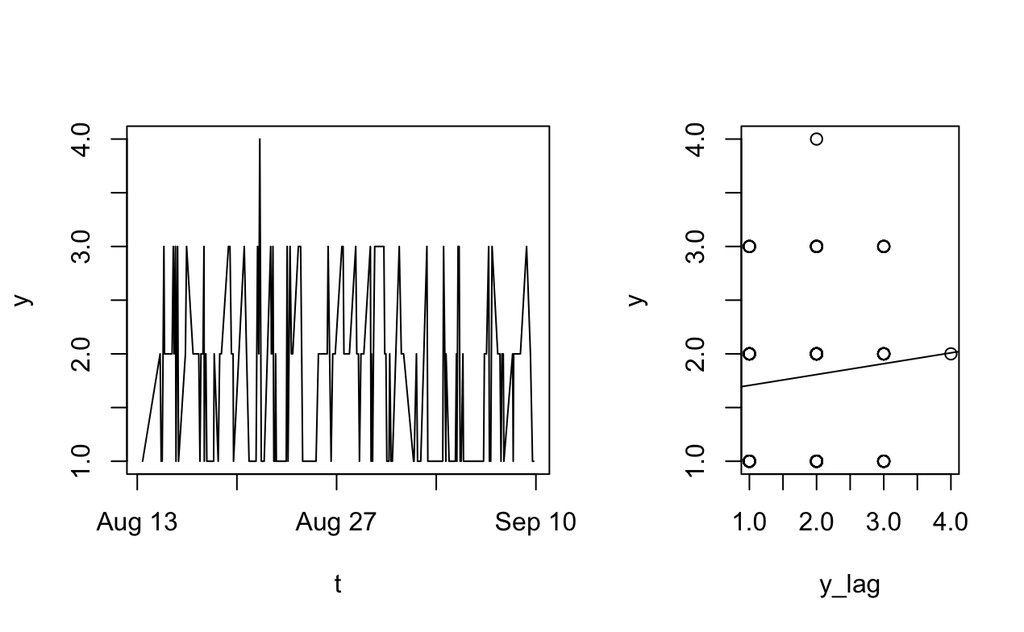

```r
layout(1)
```

```r
layout(matrix(c(1, 2), nrow = 1), widths = c(3, 2))
plotTimeSeries(dat$tired, dat$datetime)
plotScatterAuto(dat$tired, dat$tired_lag)
```

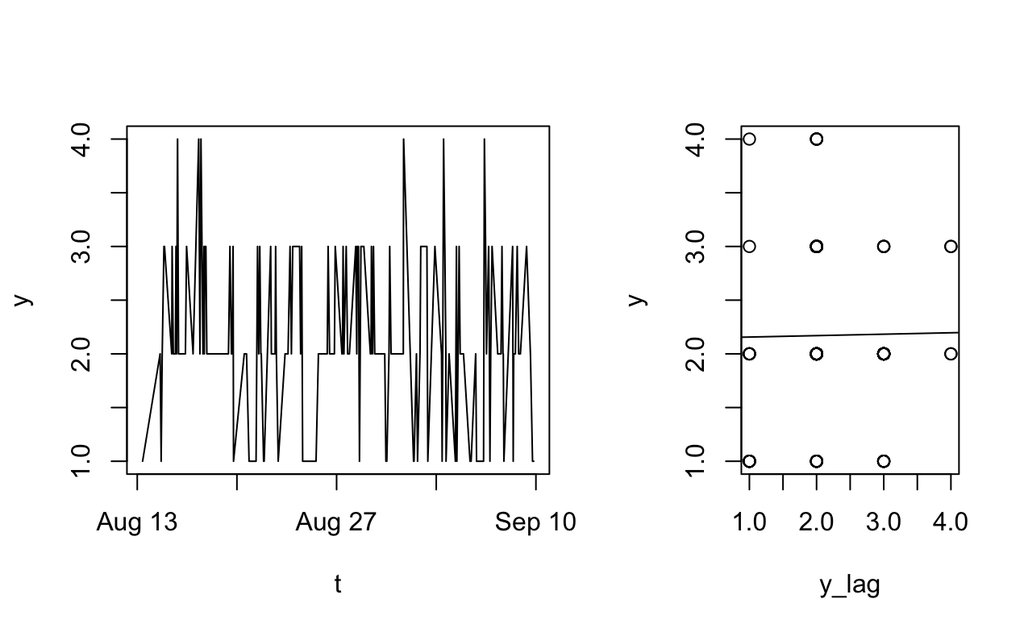

```r
layout(1)
```

### Fit the AR(1) model

Fit an AR(1) model using linear regression for `selfdoubt` and for `tired`. Center the lagged predictor if you want to intercept to represent the mean of the process.

AR(1) model for `selfdoubt`:

```r
dat$selfdoubt_lag_c <- dat$selfdoubt_lag - mean(dat$selfdoubt, na.rm = TRUE)
mod_selfdoubt <- lm(selfdoubt ~ selfdoubt_lag_c, data = dat)
mod_selfdoubt
```

```
Call:
lm(formula = selfdoubt ~ selfdoubt_lag_c, data = dat)

Coefficients:
    (Intercept)  selfdoubt_lag_c
         1.7907           0.1009
```

AR(1) model for `tired`:

```r
dat$tired_lag_c <- dat$tired_lag - mean(dat$tired, na.rm = TRUE)
mod_tired <- lm(tired ~ tired_lag_c, data = dat)
mod_tired
```

```
Call:
lm(formula = tired ~ tired_lag_c, data = dat)

Coefficients:
(Intercept)  tired_lag_c
    2.17152      0.01329
```

Answer the following questions:

- Is the estimated mean similar to the observed mean (if you estimated the intercept instead of the mean, you can compute the estimated mean using $\mu = \frac{c}{1-\phi}$)?

For `selfdoubt`, the observed mean is $1.836$, the estimated mean is $1.791$. For `tired`, the observed mean is $2.136$, the estimated mean is $2.172$.

- What are the estimates of the autoregressive effects?

For `selfdoubt` the estimated autoregressive effect is $0.1$. For `tired` the estimated autoregressive effect is $0.01$.

- How would you interpret the autoregressive effects?

### Extra exercise

If you want, you can fit the model to data from a different phase and see how the estimates differ. For example, you could take phase 4 and 5 as a post-assessment period.

```r
dat_raw <- read.csv("data_groot.csv")
dat2 <- subset(dat_raw, phase == 4 | phase == 5)
dat2
```

```r
dat2$selfdoubt_lag <- dat2$tired_lag <- NA
for (i in 2:nrow(dat2)) {
  dat2$selfdoubt_lag[i] <- ifelse((dat2$beep[i] - dat2$beep[i - 1]) == 1, dat2$selfdoubt[i - 1], NA)
  dat2$tired_lag[i] <- ifelse((dat2$beep[i] - dat2$beep[i - 1]) == 1, dat2$tired[i - 1], NA)
}
```

```r
dat2$selfdoubt_lag_c <- dat2$selfdoubt_lag - mean(dat2$selfdoubt, na.rm = TRUE)
mod_selfdoubt2 <- lm(selfdoubt ~ selfdoubt_lag_c, data = dat2)
mod_selfdoubt2
```

```r
dat2$tired_lag_c <- dat2$tired_lag - mean(dat2$tired, na.rm = TRUE)
mod_tired2 <- lm(tired ~ tired_lag_c, data = dat2)
mod_tired2
```

### References

Wichers, M., Groot, P. C., & Psychosystems, ESM Group, EWS Group. (2016). Critical Slowing Down as a Personalized Early Warning Signal for Depression. *Psychotherapy and Psychosomatics, 85*(2), 114–116. https://doi.org/10.1159/000441458

Kossakowski, J. J., Groot, P. C., Haslbeck, J. M. B., Borsboom, D., & Wichers, M. (2017). Data from ‘Critical Slowing Down as a Personalized Early Warning Signal for Depression.’ *Journal of Open Psychology Data, 5*, 1. https://doi.org/10.5334/jopd.29